# BCB420_Assignment_1

Jiayang Sun

# Data analysis

## Data set series: GSE189820

## Dataset title: Gene expression in duodenal biopsy samples from CVID enteropathy patients and healthy controls.

A subgroup of CVID patients presents with gastrointestinal complications (enteropathy), which manifests in the duodenum as celiac like-diese ase. CVID enteropathy patients can present with severe histopathology in form of villous atrophy (CVID VA) or without VA (CVID noVA). RNAseq data from CVID VA and CVID noVA derived duodenal tissues were compared to each other and to healthy controls. # Preparation Download data use the GEOquery Bioconductor package.

```r
if (!requireNamespace("BiocManager", quietly = TRUE)) install.packages("BiocManager")
library(BiocManager)
if (!requireNamespace("GEOmetadb", quietly = TRUE)) BiocManager::install("GEOmetadb")
```

```
## Setting options('download.file.method.GEOquery'='auto')
```

```
## Setting options('GEOquery.inmemory.gpl'=FALSE)
```

```r
library(GEOmetadb)
library(knitr)
library(edgeR)
```

```r
library(biomaRt)
library(ggplot2)
library(reshape2)
```

# 1. Select an Expression Data Set

```r
gse <- getGEO("GSE189820",GSEMatrix=FALSE)
```

```
## Reading file....
```

```
## Parsing....
```

[output not shown]

[output not shown]

[output not shown]

[output not shown]

[output not shown]

[output not shown]

[output not shown]

[output not shown]

[output not shown]

[output not shown]

[output not shown]

[output not shown]

[output not shown]

[output not shown]

[output not shown]

[output not shown]

[output not shown]

[output not shown]

[output not shown]

[output not shown]

[output not shown]

[output not shown]

[output not shown]

```r
kable(data.frame(head(GEOquery::Meta(gse))), format = "html")
```

| contact_address | contact_city | contact_country | contact_institute | contact_name | contact_zip.postal_code |
| --- | --- | --- | --- | --- | --- |
| Breisacherstr 153 | Freiburg | Germany | University clinics Freiburg | Geoffroy,,Andrieux | 79110 |

```r
current_gpl <- names(GPLList(gse))[1]
current_gpl_info <- Meta(getGEO(current_gpl))
```

## Information about Platform

Platform title : Illumina NextSeq 500 (Homo sapiens) Submission data : Nov 29, 2021 Last update data : Feb 10, 2023 Organims : Homo sapiens (taxid: 9606) Number of GEO datasets that use this techology : 9927 Number of GEO samples that use this technology : 291569

# 2.Clean the data and map to HUGO symbols

## Download the data

```r
sfiles = getGEOSuppFiles('GSE189820')
fnames = rownames(sfiles)
```

## Assess

Filter out low count genes according to edgeR:

```r
# Load the expression data and convert it to a matrix of raw counts
counts <- as.matrix(read.table(fnames[1], header = TRUE, row.names = 1, sep = "\t"))
# Create a DGEList object:
dge <- DGEList(counts = counts, genes = rownames(counts))
# Filter out genes that have less than 3 samples with a count-per-million (cpm) of at least 1:
keep <- rowSums(cpm(dge) >= 1) >= 3
dge_filt <- dge[keep,]
```

Filter out duplicate genes:

```r
# Identify duplicated gene names:
dup_genes <- duplicated(rownames(dge_filt))
# Subset dge_filt to exclude duplicated genes:
dge_filt_unique <- dge_filt[!dup_genes,]
```

## Map

```r
# Connect to the Ensembl database and select the human gene annotation dataset
ensembl <- useMart("ensembl", dataset = "hsapiens_gene_ensembl")
# Extract the list of gene IDs from the filtered expression data
gene_list <- rownames(dge_filt_unique)
# Retrieve gene IDs and HUGO symbols for the gene list
gene_annotations <- getBM(attributes = c("ensembl_gene_id", "hgnc_symbol"), filters = "ensembl_gene_id", values = gene_list, mart = ensembl)
rownames(gene_annotations) <- gene_annotations$ensembl_gene_id
# Map the gene counts in the filtered expression data to HUGO symbols
mapped_counts <- dge_filt_unique[match(gene_annotations$ensembl_gene_id, rownames(dge_filt_unique)),]
rownames(mapped_counts) <- make.unique(gene_annotations$hgnc_symbol)
```

## Removing outliers

```r
# Identify outliers in each gene using boxplot.stats()
outliers <- apply(mapped_counts, 1, function(x) {
  bp <- boxplot.stats(x)
  bp$out
})
# Flatten the outlier matrix into a vector
outliers <- unlist(outliers)
# Remove the outliers from mapped_counts
mapped_counts_no_outliers <- mapped_counts[, !colnames(mapped_counts) %in% outliers]
```

# Apply Normalization(TMM):

```r
if (is.data.frame(mapped_counts_no_outliers)) {
    mapped_counts_no_outliers <- as.matrix(mapped_counts_no_outliers)
} else if (is(mapped_counts_no_outliers, "DGEList")) {
    if (exists("counts", where = "package:edgeR")) {
        mapped_counts_no_outliers <- mapped_counts_no_outliers[["counts"]]
    } else {
        stop("The 'counts' method for class 'DGEList' is not available. Please install the 'edgeR' package.")
    }
}
# Calculate normalization factors using trimmed mean of M values
libSizes <- colSums(mapped_counts_no_outliers)
mapped_counts_no_outliers <- mapped_counts_no_outliers + 1
logCPM <- cpm(mapped_counts_no_outliers, log=TRUE)
keep <- rowSums(logCPM > log(1) & logCPM < log(10)) >= 2
logCPM <- logCPM[keep, ]
y <- calcNormFactors(logCPM, method = "TMM")
```

[output not shown]

[output cut: 130 more lines]

[output not shown]

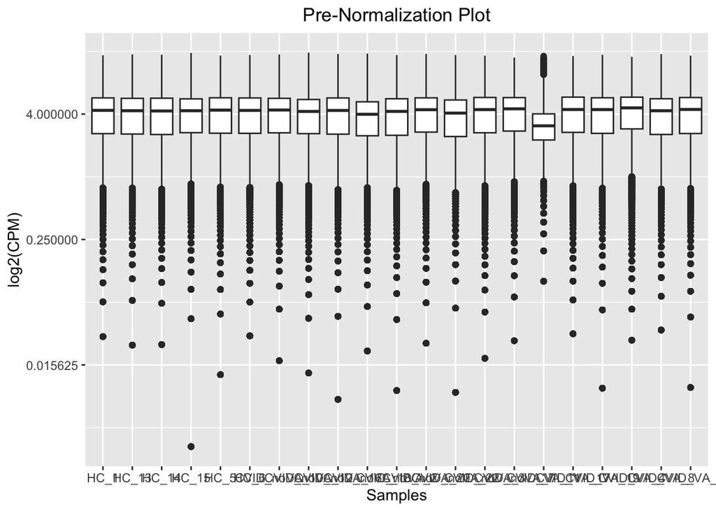

```r
# Normalize the expression data
mapped_counts_norm <- t(t(mapped_counts_no_outliers)/as.numeric(y))
# Create pre-normalization plot
logCPM_pre <- cpm(mapped_counts_no_outliers, log=TRUE)
logCPM_pre_melt <- melt(logCPM_pre)
ggplot(logCPM_pre_melt, aes(x = Var2, y = value)) +
  geom_boxplot() +
  scale_y_continuous(trans='log2') +
  xlab("Samples") +
  ylab("log2(CPM)") +
  ggtitle("Pre-Normalization Plot") +
  theme(plot.title = element_text(hjust = 0.5))
```

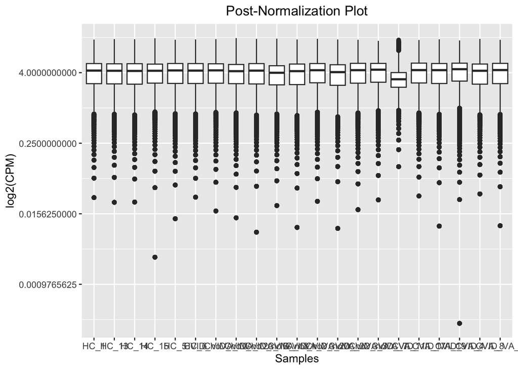

```r
# Create post-normalization plot
logCPM_post <- cpm(mapped_counts_norm, log=TRUE)
logCPM_post_melt <- melt(logCPM_post)
ggplot(logCPM_post_melt, aes(x = Var2, y = value)) +
  geom_boxplot() +
  scale_y_continuous(trans='log2') +
  xlab("Samples") +
  ylab("log2(CPM)") +
  ggtitle("Post-Normalization Plot") +
  theme(plot.title = element_text(hjust = 0.5))
```

```r
# Create final dataframe with HUGO symbols as rownames
final_data <- data.frame(mapped_counts_norm)
rownames(final_data) <- rownames(mapped_counts_norm)
```

# Interpret, and document

- What are the control and test conditions of the dataset? The dataset “GSE189820” contains gene expression data from duodenal biopsy samples of three groups: healthy controls, CVID enteropathy patients without villous atrophy (CVID noVA), and CVID enteropathy patients with villous atrophy (CVID VA). The comparisons are between CVID noVA vs healthy controls and CVID VA vs healthy controls, as well as between CVID noVA vs CVID VA. Therefore, the control conditions are the healthy controls, and the test conditions are CVID noVA and CVID VA.
- Why is the dataset of interest to you? The dataset is interesting to me because it examines gene expression in duodenal biopsy samples from CVID enteropathy patients and healthy controls. Common variable immunodeficiency (CVID) is an immune system disorder, and typically, immune system disorders are usually of unknown cause and difficult to cure. The results of this analysis can provide insights into the molecular basis of CVID enteropathy and potentially identify biomarkers for diagnosis and treatment.
- Were there expression values that were not unique for specific genes? How did you handle these? Yes, there were expression values that were not unique for specific genes. To handle this, I used the make.unique() function to add suffixes to gene names that were not unique, ensuring that each row in the final matrix had a unique HUGO symbol. This was done after mapping the gene counts in the filtered expression data to HUGO symbols using the match() function.
- Were there expression values that could not be mapped to current HUGO symbols?

```r
unmapped_genes <- setdiff(rownames(mapped_counts), gene_annotations$ensembl_gene_id)
```

Yes, the majority of expression values were successfully mapped. However, there are some expression values could not be mapped due to incomplete annotation or other issues. - How many outliers were removed?

```r
num_cols_original <- ncol(mapped_counts)
num_cols_filtered <- ncol(mapped_counts_no_outliers)
num_outliers_removed <- num_cols_original - num_cols_filtered
```